# Text as Data

Lecture 08b  
POLS 6394 · Thursday, October 15

## Today

- Text is data: speeches, survey answers, bills, tweets
- Human coding, supervised learning, and unsupervised discovery
- Count one word across 60 inaugural addresses
- A **dictionary**: a keyword list that classifies text
- A **keyword-assisted topic model** (keyATM): start from your keywords, let the model find related words
- Lab: add a foreign-affairs topic, and check what the model put in it

# Text is data

## Why text

Much of politics happens in words: speeches, platforms, bills, open-ended survey answers.

- Reading 60 speeches takes a weekend. Reading 60,000 takes a career.
- Turning text into numbers lets you count, compare, and plot it like any other variable.
- Every method today is a **measurement**. It can be wrong, so we’ll check it.

In Part II you’ll classify text with an LLM and compare it with today’s methods.

## Human coding and checking agreement

Researchers have long coded newspapers, speeches, and interviews by hand. Human coding is still how we check automated methods.

- A **codebook** defines what counts as a topic or position, such as concern about prices.
- Have two people code the same sample **independently**.
- **Intercoder reliability** describes their consistency. Report the percentage of decisions they agree on and inspect disagreements.
- Clarify ambiguous rules, then check another sample.

Agreement doesn’t establish validity: both people can consistently apply a poor definition. Coding takes time, but these examples also help evaluate automated methods.

## Computers applied keyword dictionaries

Early computerized content analysis used lists of words associated with concepts.

- Count *war*, *army*, and *military* to measure attention to conflict.
- Apply the same rule to thousands of documents quickly.
- Inspect the word list to see exactly what the measure includes.

The rule can miss synonyms and count a word in the wrong sense. We’ll start here because the connection between text and measurement is easy to inspect.

## Bag-of-words: one row per document

We turn text into numeric predictors by counting each word.

- A: “Trade creates jobs”
- B: “Trade costs jobs”
- C: “Jobs jobs jobs”

| Document | trade | creates | costs | jobs |
| --- | --- | --- | --- | --- |
| A | 1 | 1 | 0 | 1 |
| B | 1 | 0 | 1 | 1 |
| C | 0 | 0 | 0 | 3 |

Each document is a row; each word is a column. A zero means the word is absent. We can give these columns to a statistical model.

## What bag-of-words leaves out

A **bag-of-words** representation records word counts and discards their order.

> A: We support peace, not war.  
> B: We support war, not peace.

| Selected word | A | B |
| --- | --- | --- |
| support | 1 | 1 |
| peace | 1 | 1 |
| war | 1 | 1 |
| not | 1 | 1 |

The counts match even though the positions are opposite. Counting short phrases can preserve some order. Our document-feature matrix will use single-word counts. Later, our stopword list also removes *not*, so preprocessing can discard meaningful information.

## Training, testing, and the texts we want to study

A **corpus** is a collection of texts. From **1,000 tariff answers**, randomly select **100** for humans to code for price concerns as our codebook defines them. Check coding disagreements.

1. **Training corpus (80):** fit a model using these texts and labels. “Groceries cost more” is prices; “Protect American jobs” is not prices. The model learns associations between word patterns and labels.
2. **Test set (20):** randomly hold out 20 of the coded answers before training. Compare predictions with their human labels.
3. **Target texts (900):** apply the checked model to the uncoded answers, then summarize its predictions.

The training texts should resemble the target texts. Twenty test answers give only a rough accuracy check.

## Parametric and nonparametric: how much shape do we specify?

- **Parametric:** choose a model form first, then estimate its coefficients. In logistic regression, word counts get coefficients that combine into a prediction.
- **Nonparametric:** let the examples determine more of the prediction rule, rather than requiring that fixed form.
- For example, find the coded answers most similar to a new answer and let their labels vote. As we collect more examples, the rule can capture more detailed patterns.

Nonparametric doesn’t mean “no assumptions.” We still choose what counts as similar and how many neighbors vote. Flexibility can help, but it can also fit peculiarities of the training examples.

Machine learning includes both parametric and nonparametric methods.

## Supervised or unsupervised: what is the question?

**Supervised:** “Which answers mention prices?” We know the category and supply examples. The model learns to recognize it in new answers.

**Unsupervised:** “What subjects recur in these answers?” We don’t supply topic labels. The model finds patterns in the words; we then interpret and name them.

These can answer different research questions. Unsupervised topics may not line up with categories we already care about.

## How can the 900 uncoded answers help?

We still have **80 coded training answers, 20 coded test answers, and 900 uncoded answers**.

- A **supervised** classifier learns from the 80 labeled training examples.
- An **unsupervised** method can find recurring subjects in the 900 answers without using the human labels. Its topics might be prices, jobs, or something else; we have to inspect and name them.
- A **semi-supervised** method also uses patterns in the 900 uncoded answers **during fitting**.
- For example, recurring groups of similarly worded answers may help extend information from the few labeled examples.
- Compare supervised and semi-supervised price predictions on the same 20 held-out answers. Unsupervised topics need interpretation before we could treat one as a price classifier.

Uncoded text adds information about wording, not guaranteed correct labels. If similar words express different positions, using that structure can spread mistakes.

## Topic models find recurring subjects

What if we have thousands of documents but haven’t labeled their subjects?

A **topic model** estimates recurring groups of words and how much each document draws on them. LDA (latent Dirichlet allocation) is a common example.

| Illustrative top words | A label we might give the topic |
| --- | --- |
| hospital, doctor, insurance | Health care |
| army, defense, border | Security |

A speech can mix both topics. The model estimates word patterns; we read passages to decide whether our labels fit.

## Setup

Two new packages: **quanteda** handles text, and **keyATM** fits the topic model. If either isn’t installed, run `install_packages.R` first.

```r
library(tidyverse)
library(quanteda)
library(keyATM)
```

## Sixty inaugural addresses

quanteda includes every presidential inaugural address, 1789–2025. `convert()` turns it into a data frame; we keep four columns.

```r
speeches <- convert(data_corpus_inaugural, to = "data.frame") |>
  as_tibble() |>
  select(year = Year, president = President, party = Party, text)

nrow(speeches)
```

```
[1] 60
```

One row is one speech. The whole speech is in `text`, one long string.

## Ten random speeches

```r
set.seed(6394)
speeches |>
  slice_sample(n = 10) |>
  mutate(text = str_trunc(text, 50))
```

```
# A tibble: 10 × 4
    year president  party                 text
   <int> <chr>      <fct>                 <chr>
 1  1905 Roosevelt  Republican            "My fellow citizens, no people on ear…
 2  1997 Clinton    Democratic            "My fellow citizens: At this last pre…
 3  1937 Roosevelt  Democratic            "When four years ago we met to inaugu…
 4  1981 Reagan     Republican            "Senator Hatfield, Mr. Chief Justice,…
 5  1797 Adams      Federalist            "When it was first perceived, in earl…
 6  2021 Biden      Democratic            "Chief Justice Roberts, Vice Presiden…
 7  1865 Lincoln    Republican            "Fellow-Countrymen:\n\nAt this second…
 8  1789 Washington none                  "Fellow-Citizens of the Senate and of…
 9  1817 Monroe     Democratic-Republican "I should be destitute of feeling if …
10  1969 Nixon      Republican            "Senator Dirksen, Mr. Chief Justice, …
```

`str_trunc()` shortens each speech to 50 characters so the table fits.

## Read the opening of one

`str_sub()` takes characters by position: here, the first 300 of Lincoln’s second inaugural.

```r
speeches |>
  filter(year == 1865) |>
  pull(text) |>
  str_sub(1, 300)
```

```
[1] "Fellow-Countrymen:\n\nAt this second appearing to take the oath of the Presidential office there is less occasion for an extended address than there was at the first. Then a statement somewhat in detail of a course to be pursued seemed fitting and proper. Now, at the expiration of four years, d…
```

`pull()` takes one column out as a vector, so we get the text itself rather than a tibble.

# Counting words

## How long is each speech?

`str_count()` counts matches of a pattern. `"\\S+"` matches a run of non-space characters, which is one word.

```r
speeches <- speeches |>
  mutate(n_words = str_count(text, "\\S+"))

speeches |>
  select(year, president, n_words) |>
  slice_max(n_words, n = 3)
```

```
# A tibble: 3 × 3
   year president n_words
  <int> <chr>       <int>
1  1841 Harrison     8465
2  1909 Taft         5430
3  1845 Polk         4810
```

`str_count()` is vectorized: one call counts all 60 speeches.

## Count one word

`\\b` marks a word boundary, so `"\\bwar\\b"` matches *war* but not *warm* or *award*. `str_to_lower()` makes *War* and *war* the same.

```r
speeches <- speeches |>
  mutate(war = str_count(str_to_lower(text), "\\bwar\\b"))

speeches |>
  select(year, president, war) |>
  slice_max(war, n = 3)
```

```
# A tibble: 3 × 3
   year president   war
  <int> <chr>     <int>
1  1821 Monroe       16
2  1813 Madison      15
3  1921 Harding      15
```

## Counts depend on length

A long speech has more chances to say anything. Divide by length to get a **rate**: mentions per 1,000 words.

```r
speeches <- speeches |>
  mutate(war_rate = 1000 * war / n_words)

speeches |>
  select(year, president, war, war_rate) |>
  slice_max(war_rate, n = 3)
```

```
# A tibble: 3 × 4
   year president   war war_rate
  <int> <chr>     <int>    <dbl>
1  1865 Lincoln      12    17.1
2  1813 Madison      15    12.4
3  1921 Harding      15     4.51
```

Lincoln in 1865 says *war* less often than Monroe in 1821, but at a much higher rate.

## War across two centuries

The line connects consecutive inaugural addresses, with mentions adjusted for speech length.

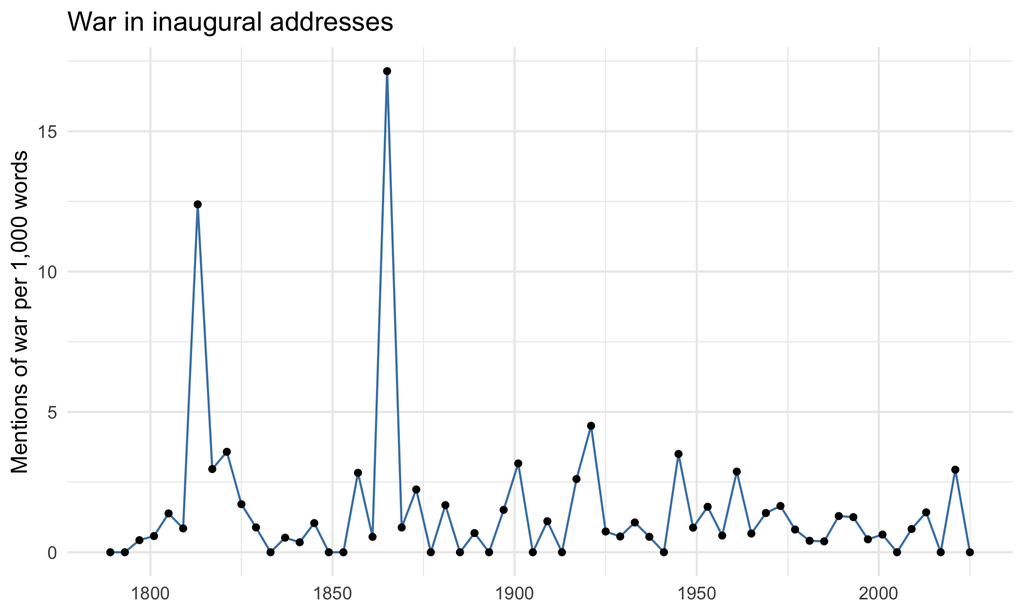

```r
speeches |>
  ggplot(aes(x = year, y = war_rate)) +
  geom_line(color = "steelblue") +
  geom_point(size = 1.2) +
  labs(
    title = "War in inaugural addresses",
    x = NULL,
    y = "Mentions of war per 1,000 words"
  ) +
  theme_minimal()
```

## Your Turn: count another word

*~3 minutes*

Pick a word you think has risen or fallen over time, such as *freedom*, *trade*, *world*, or *union*. Count it per 1,000 words and plot it.

```r
speeches |>
  mutate(rate = 1000 * str_count(str_to_lower(text), "\\b___\\b") / n_words) |>
  ggplot(aes(x = year, y = rate)) +
  geom_point() +
  labs(title = "My chosen word over time", x = NULL, y = "Mentions per 1,000 words") +
  theme_minimal()
```

What pattern do you see? Does it match what you expected?

# A dictionary

## One word is fragile

*War* misses *wars*, *military*, *defense*, and *army*. A **dictionary** is a list of keywords for one concept. A speech’s score is how often it uses any of them.

Inside a pattern, `|` means “or.” `paste()` with `collapse = "|"` joins a list into one pattern:

```r
paste(c("war", "peace", "military"), collapse = "|")
```

```
[1] "war|peace|military"
```

## A function that scores a dictionary

The same steps as the *war* rate, with any list of words. `"\\b("` and `")\\b"` put word boundaries around the whole list.

```r
dict_rate <- function(text, words) {
  pattern <- paste0("\\b(", paste(words, collapse = "|"), ")\\b")
  hits <- str_count(str_to_lower(text), pattern)
  result <- 1000 * hits / str_count(text, "\\S+")
  return(result)
}

dict_rate("War and peace. Peace!", c("war", "peace"))
```

```
[1] 750
```

## Word forms and stemming

Our dictionary matches whole words: *tariff* doesn’t match *tariffs*. **Stemming** shortens words to combine related forms. quanteda’s `char_wordstem()` shows what happens:

```r
forms <- c("tariff", "tariffs", "economy", "economic", "imports", "important")
tibble(word = forms, stem = char_wordstem(forms, language = "english"))
```

```
# A tibble: 6 × 2
  word      stem
  <chr>     <chr>
1 tariff    tariff
2 tariffs   tariff
3 economy   economi
4 economic  econom
5 imports   import
6 important import
```

*Tariff/tariffs* merge, but *economy/economic* don’t. *Imports/important* also merge, incorrectly for trade. Today we keep whole words. If we stem a model, we must stem both the texts and keyword lists, then check the matches.

## Five keyword dictionaries

A named list holds one keyword list per concept. We’ll use the same lists for the topic model.

```r
dictionaries <- list(
  government = c("constitution", "congress", "federal", "government",
    "executive", "administration", "laws"),
  war = c("war", "peace"),
  rights = c("freedom", "liberty", "rights", "justice", "equal", "civil"),
  union = c("union", "states"),
  identity = c("america", "american", "americans", "nation")
)
```

These are judgment calls. Someone else might choose different words, and that’s the point of checking.

## Score every speech on each

`dict_rate()` is vectorized, so each line scores all 60 speeches at once.

```r
dict_scores <- speeches |>
  mutate(
    government = dict_rate(text, dictionaries$government),
    war = dict_rate(text, dictionaries$war),
    rights = dict_rate(text, dictionaries$rights),
    union = dict_rate(text, dictionaries$union),
    identity = dict_rate(text, dictionaries$identity)
  ) |>
  select(year, president, government, war, rights, union, identity)

dict_scores |>
  slice_max(war, n = 3)
```

```
# A tibble: 3 × 7
   year president government   war rights union identity
  <int> <chr>          <dbl> <dbl>  <dbl> <dbl>    <dbl>
1  1865 Lincoln         1.43  18.6   1.43  5.71     5.71
2  1945 Roosevelt       1.75  14.0   3.50  0        3.50
3  1813 Madison         3.31  12.4   4.13  3.31     4.13
```

## Your Turn: one more dictionary

*~3 minutes*

Add a foreign-affairs column with `dict_rate()`. Use words such as *foreign*, *nations*, *world*.

```r
speeches |>
  mutate(foreign = dict_rate(text, c(___))) |>
  select(year, president, foreign) |>
  slice_max(foreign, n = 5)
```

Which presidents top the list? Does that fit what you know about them?

## Plot the dictionaries over time

`pivot_longer()` stacks government, war, and union so `facet_wrap()` can draw one panel each. `span` sets how closely the trend line follows the points: smaller is wigglier.

```r
dict_scores |>
  pivot_longer(c(government, war, union), names_to = "dictionary", values_to = "rate") |>
  ggplot(aes(x = year, y = rate)) +
  geom_point(alpha = 0.5) +
  geom_smooth(se = FALSE, span = 0.5) +
  facet_wrap(~dictionary) +
  labs(title = "Government, war, and union: dictionary scores", x = NULL, y = "Keywords per 1,000 words") +
  theme_minimal()
```

## Plot the dictionaries over time

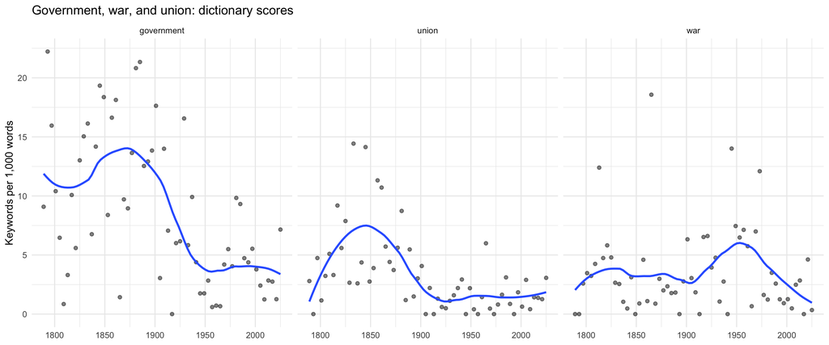

## What a dictionary can’t do

- **It misses synonyms you didn’t list.** “Our armed forces” never says *military*.
- **It counts words out of context.** *Union* means the nation in 1861 and a labor union in 1937.
- **It only knows what you told it.** It can’t notice that *peace* travels with *nations* and *treaty*.

A topic model learns which words travel together. A keyword-assisted one starts from your lists.

# A topic model with keywords

## The idea

An ordinary topic model finds recurring word patterns without supplied topic labels. **keyATM adds keyword guidance**:

- We suggest words such as *war*, *peace*, and *military*.
- The model learns related words and each speech’s mix of topics.
- Additional topics can capture patterns outside our lists.

This is **weak supervision**: keywords provide partial guidance, rather than a correct label for each speech. It differs from training with a mixture of labeled and unlabeled documents.

**Steps 1–4 are supplied:** run them and read what they print; you won’t write this code.

## Who built keyATM?

- **Shusei Eshima, Kosuke Imai, and Tomoya Sasaki**, “[Keyword-Assisted Topic Models](https://doi.org/10.1111/ajps.12779),” *American Journal of Political Science* 68(2), 2024.
- **Kosuke Imai** (Harvard, Government and Statistics) is a prolific political methodologist, working on causal inference, survey methods, and text.
- He wrote the textbook *Quantitative Social Science: An Introduction* and co-authored widely used R packages, including **MatchIt** (matching) and **wru** (predicting race and ethnicity from names).
- keyATM is open source on CRAN. Its [website](https://keyatm.github.io/keyATM/) has tutorials that use these same inaugural addresses.

Political scientists build many of the tools you’ll use. Reading the paper behind a package tells you what it assumes.

## Step 1: split the text into words

`tokens()` splits each speech into words, called **tokens**.

```r
toks <- tokens(
  data_corpus_inaugural,
  remove_punct = TRUE, remove_numbers = TRUE, remove_symbols = TRUE
) |>
  tokens_tolower()

toks[["1789-Washington"]][1:12]
```

```
 [1] "fellow-citizens" "of"              "the"             "senate"
 [5] "and"             "of"              "the"             "house"
 [9] "of"              "representatives" "among"           "the"
```

The corpus already names each speech. `toks[["1789-Washington"]]` selects it by name; `[1:12]` shows its first 12 tokens.

## Step 2: drop the filler

Removing common words is a modeling choice: *the* and *of* rarely distinguish these speeches. We use `stopwords("english")` plus words inaugurals overuse.

```r
filler <- c(stopwords("english"), "shall", "may", "can", "must", "upon",
            "will", "us", "one", "every", "let", "made", "now", "much", "great")

toks <- toks |>
  tokens_remove(filler) |>
  tokens_select(min_nchar = 3)

toks[["1789-Washington"]][1:12]
```

```
 [1] "fellow-citizens" "senate"          "house"           "representatives"
 [5] "among"           "vicissitudes"    "incident"        "life"
 [9] "event"           "filled"          "greater"         "anxieties"
```

`tokens_select(min_nchar = 3)` also drops one- and two-letter fragments.

## Step 3: count words per speech

A **document-feature matrix** (dfm) has one row per speech and one column per word. Each cell is a count.

```r
speech_dfm <- dfm(toks) |>
  dfm_trim(min_termfreq = 5, min_docfreq = 2)

dim(speech_dfm)
```

```
[1]   60 2633
```

```r
topfeatures(speech_dfm, n = 5)
```

```
    people government     states      world     nation
       592        575        343        329        324
```

`min_termfreq = 5` keeps words used at least five times across the whole corpus. `min_docfreq = 2` keeps words found in at least two speeches. A word must pass both checks. `topfeatures(n = 5)` prints the five most frequent words.

## Choose frequent keywords

The model receives the same named list we used for dictionary counts. Each name defines a guided topic.

```r
dictionaries$union
```

```
[1] "union"  "states"
```

```r
dictionaries$identity
```

```
[1] "america"   "american"  "americans" "nation"
```

These are two of the five lists; `keywords = dictionaries` passes all five. The [keyATM guide](https://keyatm.github.io/keyATM/articles/pkgdown_files/Preparation.html#checking-keywords) recommends frequent keywords, typically above **0.1% of the corpus**. Our retained corpus has 51,589 tokens, so that is about **52 uses**. Every keyword here passes. This screens out weak guidance, but does not guarantee a coherent topic.

## Check keyword frequencies

`keyATM_read()` puts the dfm into the form keyATM uses. `visualize_keywords()` plots each keyword’s share of all kept words, one line per keyword list.

```r
keyatm_docs <- keyATM_read(texts = speech_dfm)

visualize_keywords(docs = keyatm_docs, keywords = dictionaries)
```

The y-axis is in percent. The lowest point, *civil*, is about 0.11, just above the 0.1% guideline, so every keyword passes.

## Check keyword frequencies

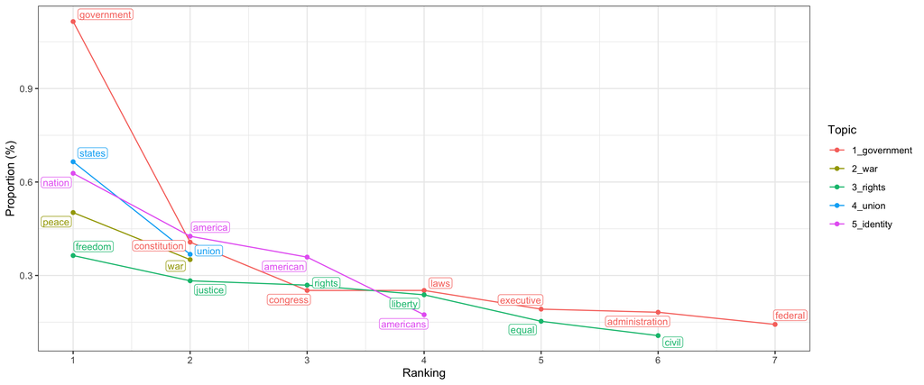

## Step 4: fit the model

`keyATM()` fits the model with our five keyword lists plus one topic without keywords.

```r
topic_model <- keyATM(
  docs = keyatm_docs,
  keywords = dictionaries,
  no_keyword_topics = 1,
  model = "base",
  options = list(seed = 6394, iterations = 1500, verbose = FALSE)
)
```

The model starts from random guesses and updates its estimates 1,500 times, each pass starting from the last. `seed` fixes the random start, so it comes out the same every run. It takes a few seconds.

## How many topics?

Our five keyword lists define five guided topics. `no_keyword_topics = 1` adds one more: **six topics total**. Adding foreign affairs in the lab gives seven.

- Too few topics can mix distinct subjects.
- Too many can split one subject into near-duplicates or unstable topics.
- Compare top words **and passages**, and check whether the findings hold across topic counts and random seeds.

There isn’t one correct number for every dataset. Statistical fit is useful, but doesn’t establish that a topic measures what we intended. Extension 1 lets you compare specifications.

## Step 5: read the topics

`top_words()` lists each topic’s most typical words. `n = 6` requests six words per topic. Here we show all five guided topics. `starts_with("Other")` selects names beginning with Other; the minus excludes those columns. ✓ marks a keyword for that topic; a bracketed number marks a keyword from another list.

```r
top_words(topic_model, n = 6) |>
  select(-starts_with("Other"))
```

```
      1_government     2_war    3_rights    4_union   5_identity
1   government [✓] peace [✓]     nations states [✓]   nation [✓]
2           people    united freedom [✓]  union [✓]          new
3           public   war [✓]    national      power  america [✓]
4          country   without        good   citizens         time
5 constitution [✓]     right justice [✓]       duty american [✓]
6     congress [✓] political  rights [✓]      state         make
```

## Read the other topic too

Other_1 has no keyword list. Its name is a placeholder; read the words before deciding what it represents.

```r
top_words(topic_model, n = 6) |>
  select(starts_with("Other"))
```

```
  Other_1
1   world
2  people
3    life
4    know
5 history
6    free
```

## Check the learned topics

- **Government:** government, people, public, country, constitution, congress.
- **War:** peace and war, alongside united, without, right, and political.
- **Rights:** freedom, justice, and rights, mixed with nations and national.
- **Union:** states and union lead; power, citizens, duty, and state also appear.
- **Identity:** nation, america, and american, alongside new, time, and make.

The keyword lists guide the fit, but don’t guarantee a coherent topic. Check the words and passages.

## Each speech is a mix

`theta` holds each speech’s estimated share of each topic, among the words the model kept. Each row adds up to 1. `bind_cols()` attaches year, president, and party; the rows are in the same order.

```r
topic_shares <- as_tibble(topic_model$theta) |>
  bind_cols(select(speeches, year, president, party))

topic_shares |>
  select(year, president, `1_government`, `2_war`, `3_rights`) |>
  slice_max(`2_war`, n = 3)
```

```
# A tibble: 3 × 5
   year president `1_government` `2_war` `3_rights`
  <int> <chr>              <dbl>   <dbl>      <dbl>
1  1813 Madison            0.162   0.299      0.158
2  1821 Monroe             0.264   0.256      0.134
3  1809 Madison            0.233   0.210      0.185
```

Backticks let you use column names that start with a number.

## Topics over time: reshape first

Start with three topic columns. Pivot them into a topic name and a share, so each speech has one row per topic.

```r
topic_long <- topic_shares |>
  select(year, president, `1_government`, `2_war`, `3_rights`) |>
  pivot_longer(c(`1_government`, `2_war`, `3_rights`),
    names_to = "topic", values_to = "share") |>
  mutate(topic = recode(topic,
    "1_government" = "Government", "2_war" = "War", "3_rights" = "Rights"))

topic_long |>
  filter(year == 1949)
```

```
# A tibble: 3 × 4
   year president topic       share
  <int> <chr>     <chr>       <dbl>
1  1949 Truman    Government 0.0697
2  1949 Truman    War        0.134
3  1949 Truman    Rights     0.300
```

Truman’s speech now has three rows rather than three separate topic columns.

## Topics over time

With long data, every panel uses `year` and `share`; `facet_wrap()` uses `topic` to split the panels. Check the learned words before interpreting the trends.

```r
ggplot(topic_long, aes(x = year, y = share)) +
  geom_point(alpha = 0.5) +
  geom_smooth(se = FALSE, span = 0.5) +
  facet_wrap(~topic) +
  labs(title = "Estimated shares for keyword-seeded topics",
    x = NULL, y = "Estimated share of kept words") +
  theme_minimal()
```

## Topics over time

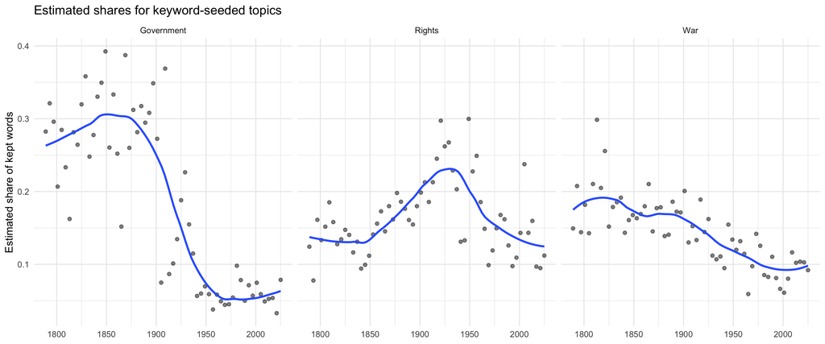

## From the Union to American identity

Did speeches shift from preserving the Union to emphasizing a shared American identity? Compare the union and identity topics. Identity also picks up modern rhetoric, so inspect passages before interpreting its rise.

```r
topic_shares |>
  pivot_longer(c(`4_union`, `5_identity`),
    names_to = "topic", values_to = "share") |>
  mutate(topic = recode(topic,
    "4_union" = "Union", "5_identity" = "American identity")) |>
  ggplot(aes(x = year, y = share)) +
  geom_point(alpha = 0.5) +
  geom_smooth(se = FALSE, span = 0.5) +
  facet_wrap(~topic) +
  labs(title = "The Union and American identity",
    x = NULL, y = "Estimated share of kept words") +
  theme_minimal()
```

## From the Union to American identity

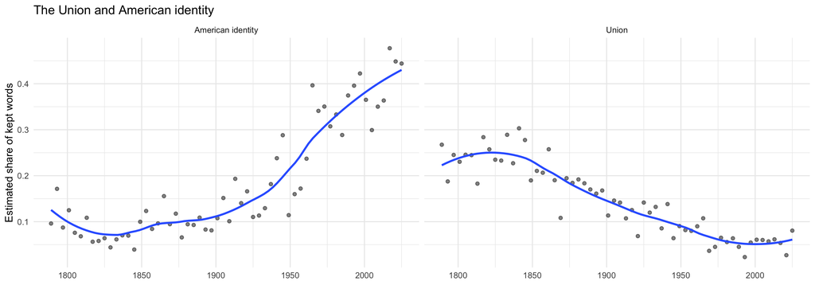

## Your Turn: which speeches are most about rights?

*~3 minutes*

Find the five speeches with the largest share of the rights topic. The column name starts with a number, so it needs backticks: `` `3_rights` ``.

```r
topic_shares |>
  slice_max(___, n = 5) |>
  select(year, president, `3_rights`)
```

## Your Turn: read one of them

*~3 minutes*

`topic_shares` has no text, so go back to the corpus. `corpus_subset()` keeps matching speeches; `kwic()` (keywords in context) prints each rights keyword with six words on either side.

```r
data_corpus_inaugural |>
  corpus_subset(Year == ___) |>
  tokens() |>
  kwic(dictionaries$rights, window = 6)
```

How often does the speech use the keywords? Do these passages use them in the sense you expected?

## Dictionary or topic model?

|  | Dictionary | Keyword topic model |
| --- | --- | --- |
| You supply | every word | a few seed words |
| Finds new words | no | yes |
| Easy to explain | very | harder |
| Text length | Can score short answers | Usually works better with longer texts |

Both are measurements. Before you use either in a paper, check it against texts a person has coded. Problem Set 03 does this for a dictionary.

# Lab

## Lab: change the topics

*~15–20 minutes.* Start in class; finish by 7:00 PM Monday, October 19.

1. **Add a foreign-affairs topic:** use your foreign-affairs dictionary words as a sixth keyword list, refit, and read its top words.
2. **Check the fit:** inspect keyword frequencies, and see where *world* lands before and after the refit.
3. **Compare parties:** using the original five-keyword model, average government and war topic shares for Democratic and Republican speeches since 1900, and write one sentence about the difference.

## Lab: save these results

- Your refit model’s top words, with the foreign topic.
- The keyword-frequency plot and one or two sentences on where *world* moved.
- A table of average government and war topic shares by party since 1900, and one sentence interpreting it.

## Before Next Class

Save, render, inspect your changes, commit, push, and confirm the commit on GitHub. If unfinished code stops the render, put `#| eval: false` back on that chunk and still push.

- **Today:** CV and website milestone: both render.
- **By 7:00 PM Monday, October 19:** finish the lab and push.
- **Problem Set 03** is due **Tuesday, October 20, 10:00 AM**: functions and iteration on text, and checking a keyword classifier against human coders.
- **Tuesday:** getting data from APIs.

# If Time Remains

## Extension 1a: change the seed

*~8 minutes.*

A different `seed` can give somewhat different topics. Refit and compare.

```r
topic_model_2 <- keyATM(
  docs = keyatm_docs,
  keywords = dictionaries,
  no_keyword_topics = 1,
  model = "base",
  options = list(seed = ___, iterations = 1500, verbose = FALSE)
)

top_words(topic_model_2, n = 6) |>
  select(-starts_with("Other"))
```

Which topic changed most? What does that mean for reporting one run?

## Extension 1b: change the topic count

*~5 minutes.*

Keep the keywords and seed fixed. Change only the number of additional topics to 3 or 5, giving 8 or 10 total.

```r
topic_model_k <- keyATM(
  docs = keyatm_docs,
  keywords = dictionaries,
  no_keyword_topics = ___,
  model = "base",
  options = list(seed = 6394, iterations = 1500, verbose = FALSE)
)
top_words(topic_model_k, n = 5) |>
  select(`1_government`, `2_war`, `4_union`)
```

Compare government, war, and union with the original fit. Which became clearer or more mixed? The column numbers may match, but the learned word groups can change.

## Extension 2: Lincoln versus Trump

*~8 minutes.*

Compare two speeches’ topic mixes side by side.

```r
topic_shares |>
  filter(year %in% c(1865, 2025)) |>
  pivot_longer(-c(year, president, party), names_to = "topic", values_to = "share") |>
  ggplot(aes(x = share, y = topic, fill = president)) +
  geom_col(position = "dodge") +
  labs(title = "Topic mix: Lincoln 1865 and Trump 2025", x = "Estimated share of kept words", y = NULL, fill = NULL) +
  theme_minimal()
```

Which topics separate the two speeches most? Read the top words of an **Other** topic before you interpret it.

## Extension 2: Lincoln versus Trump

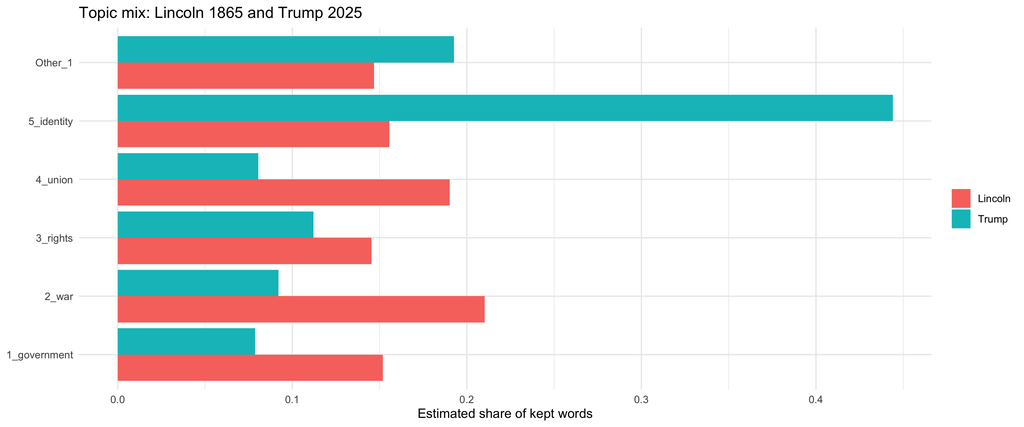

## Extension 3: read foreign-affairs passages

*~5 minutes.*

Truman’s 1949 speech is among the highest on the foreign-affairs topic in the refit. Check six keyword passages; `slice_head(n = 6)` limits the printed excerpts.

```r
data_corpus_inaugural |>
  corpus_subset(Year == 1949) |>
  tokens() |>
  kwic(foreign_keywords$foreign, window = 6) |>
  slice_head(n = 6)
```

Do these uses of *world* and *nations* all mean foreign affairs?

## Reference: context-aware models

Modern language models can use word order and surrounding passages to interpret an answer.

Counting *tariff* tells us how often it is mentioned. Studying support also requires distinguishing “tariffs protect jobs” from “tariffs hurt consumers.”

We compare methods using accuracy, cost, transparency, and available training data. A context-aware model still needs evaluation against human-coded examples.

Background: [Gentzkow, Kelly, and Taddy, Text as Data](https://web.stanford.edu/~gentzkow/research/text-as-data.pdf).